# Estadística descriptiva

MSc. Darío Alvarado

[figure not shown]

La estadística descriptiva es la que describe, analiza y representa un conjunto de datos utilizando métodos numéricos y gráficos para resumir y presentar la información que estos contienen. La estadística descriptiva se utiliza cuando los resultados del estudio no pretenden ir más allá del conjunto de datos. Su objetivo es describir las características principales de un conjunto de datos sin hacer inferencias sobre una población más grande.

#### Paquetes

```r
library(rio)
library(modeest)
library(skimr)
library(psych)
library(palmerpenguins)
library(visdat)
library(FSA)
library(collapse)
library(SmartEDA)
library(tidyverse) # El paquete `tidyverse` es una coleccion de paquetes que sirven para manejar, modificar y visualizar datos
```

### Contenido

#### Datos

```r
datos <- import("data/medidas_personas.csv")
head(datos)
```

```
##   sexo altura peso edad
## 1    M    170   71   47
## 2    M    162   79   36
## 3    M    149   86   43
## 4    M    181   97   23
## 5    M    156   98   29
## 6    M    165  107   49
```

```r
datos$sexo <- as.factor(datos$sexo)
# Convertir las variables de clase `caracter` (texto) a clase `factor` para trabajar en R. Esto lo hacemos con la función `as.factor()` o simplemente con `factor()`.
# La clase o tipo `factor` se usa para representar un vector como datos categóricos agrupados en diferentes niveles, en este caso, los niveles de nuestra variable sexo serian "M" (masculino) y "F" (femenino).

head(datos)
```

```
##   sexo altura peso edad
## 1    M    170   71   47
## 2    M    162   79   36
## 3    M    149   86   43
## 4    M    181   97   23
## 5    M    156   98   29
## 6    M    165  107   49
```

Volver arriba

Inicio

#### Medidas de tendencia central

Son medidas que nos ayudan a resumir nuestros datos en valores “típicos” que caracterizan la muestra. Indican donde se concentra la mayoría de los datos. Las medidas de tendencia central más conocidas son la **media**, la **mediana** y la **moda**

- **Media**: Suma de todos los valores dividida por el número total de observaciones.

$$\bar{X} = \frac{\sum X_i}{n}$$

Donde:

- $\bar{X}$ es la media
- $X_i$ representa cada uno de los valores del conjunto de datos
- $n$ es el número total de observaciones

```r
mean(datos$altura)
```

```
## [1] 160.04
```

```r
mean(datos$peso)
```

```
## [1] 74.44
```

```r
mean(datos$edad)
```

```
## [1] 34.71
```

- **Mediana**: Valor que divide el conjunto de datos en dos partes iguales.

Si el número de observaciones $n$ es impar, la mediana se calcula como:

$$\tilde{X} = X_{\left(\frac{n+1}{2}\right)}$$

Donde:

- $\tilde{X}$ : Mediana del conjunto de datos
- $X_{(k)}$ : Valor en la posición $k$ cuando los datos están ordenados de menor a mayor
- $n$ : Número total de observaciones
- $\frac{n+1}{2}$ : Índice que indica la posición central en la lista ordenada

Ejemplo: Si $n = 5$, la posición de la mediana es:

$$\frac{5+1}{2} = \frac{6}{2} = 3$$

El tercer valor en la lista ordenada es la mediana. Es decir, la mediana es el valor que ocupa la posición central.

Si el número de observaciones $n$ es par, la mediana se obtiene como:

$$\tilde{X} = \frac{X_{\left(\frac{n}{2}\right)} + X_{\left(\frac{n}{2} +
1\right)}}{2}$$

Donde:

- $\tilde{X}$ : Mediana del conjunto de datos
- $X_{(k)}$ : Valor en la posición $k$ cuando los datos están ordenados
- $n$ : Número total de observaciones
- $\frac{n}{2}$ : Índice del primer valor central
- $\frac{n}{2} + 1$ : Índice del segundo valor central
- $\frac{X_a + X_b}{2}$ : Promedio de los dos valores centrales

Ejemplo: Si $n = 6$, los valores centrales están en las posiciones:

$$\frac{6}{2} = 3 \quad \text{y} \quad \frac{6}{2} + 1 = 4$$

La mediana será el promedio del tercer y cuarto valor en la lista ordenada. En este caso, la mediana es el promedio de los dos valores centrales.

```r
median(datos$altura)
```

```
## [1] 160
```

```r
median(datos$peso)
```

```
## [1] 73
```

```r
median(datos$edad)
```

```
## [1] 34.5
```

- **Moda**: Valor o valores que ocurren con mayor frecuencia en el conjunto de datos.

Para un conjunto de datos discretos (listas de números enteros o categorías), la moda se define como:

$$\text{Moda} = X_i \quad \text{tal que} \quad f(X_i) \text{ es máximo}$$

Donde:

- $X_i$ es el valor de los datos
- $f(X_i)$ es la frecuencia absolula de $X_i$ (cantidad de veces que aparece en el conjunto de datos)

Para datos agrupados (variables continuas en intervalos):

$$\text{Moda} = L + \frac{(f_1 - f_0)}{(2f_1 - f_0 - f_2)} \times h$$

Donde:

- $L$ : Límite inferior del intervalo modal.
- $f_1$ : Frecuencia del intervalo modal.
- $f_0$ : Frecuencia del intervalo anterior al modal.
- $f_2$ : Frecuencia del intervalo siguiente al modal.
- $h$ : Amplitud del intervalo.

En R, la moda no tiene una función incorporada como mean() o median(), pero podemos utilizar la función `mlv()` (most likely values) del paquete `modeest` que nos devuelve el o los valores más frecuentes (que más se repiten) en nuestro conjunto de datos.

```r
mlv(datos$altura)
```

```
## [1] 139 160
```

```r
# aquí aparecen dos modas, eso quiere decir que que esa variable, las observaciones que más se repiten son esos dos valores, y que se repiten la misma cantidad de veces.
```

```r
table(datos$altura)
```

```
##
## 130 133 136 137 139 140 141 142 143 144 146 147 148 149 150 151 152 154 155 156
##   3   1   1   1   6   1   1   2   2   1   1   2   1   4   2   2   3   1   2   3
## 157 158 159 160 161 162 163 165 166 167 169 170 171 172 173 174 178 179 180 181
##   3   1   2   6   1   4   4   2   1   4   2   3   5   3   2   1   4   1   1   3
## 182 184 189 190 191 192
##   1   1   1   1   1   2
```

```r
# con la función `table()` podemos observar que los valores 139 y 160 se repiten 6 veces cada uno en la variable altura.
```

```r
mlv(datos$peso)
```

```
## [1] 64
```

```r
mlv(datos$edad)
```

```
## [1] 50
```

Volver arriba

Inicio

#### Medidas de dispersión

Las medidas de dispersión muestran la **variabilidad** de nuestro conjunto de datos. A mayor variabilidad en nuestros datos, mayor será la **incertidumbre** en los valores de los parámetros estimados para ese conjunto de datos.

- **Varianza**: Mide la dispersión de los datos con respecto a la media. Es el promedio de las diferencias al cuadrado respecto a la media. Su fórmula varía según si se trata de una población o una muestra.

Para una población:

$$\sigma^2 = \frac{\sum(X_i - \mu)^2}{N}$$

Para una muestra:

$$s^2 = \frac{\sum(X_i - \bar{X})^2}{n-1}$$

Donde:

- $\sigma^2$ : Varianza poblacional
- $s^2$ : Varianza muestral
- $N$ : Número total de elementos en la población
- $n$ : Número total de elementos en la muestra
- $X_i$ : Cada valor observado
- $\mu$ : Media poblacional
- $\bar{X}$ : Media muestral

Por defecto R aplica la fórmula para calcular la varianza muestral con el denominador $n - 1$:

```r
var(datos$altura)
```

```
## [1] 230.9479
```

```r
var(datos$peso)
```

```
## [1] 238.5519
```

```r
var(datos$edad)
```

```
## [1] 96.41
```

Al trabajar con una población completa es correcto utilizar la varianza poblacional. Para calcularla debemos modificar manualmente el factor de corrección multiplicando por $\frac{(n - 1)}{n}$ para pasar a denominador $N$:

```r
var(datos$altura) * (length(datos$altura) - 1) / length(datos$altura)
```

```
## [1] 228.6384
```

También podemos escribir la fórmula de la varianza poblacional directamente:

```r
mean((datos$altura - mean(datos$altura))^2)
```

```
## [1] 228.6384
```

- **Desviación estándar**: Mide la dispersión de los datos con respecto a la media (indica cuánto se alejan los datos de la media). Es la raíz cuadrada de la varianza. Su fórmula depende de si se calcula para una población o una muestra.

Para una población:

$$\sigma = \sqrt{\frac{\sum(X_i - \mu)^2}{N}}$$

Para una muestra:

$$s = \sqrt{\frac{\sum(X_i - \bar{X})^2}{n-1}}$$

Donde:

- $\sigma$ : Desviación estándar poblacional
- $s$ : Desviación estándar muestral
- $N$ : Número total de elementos en la población
- $n$ : Número total de elementos en la muestra
- $X_i$ : Cada valor observado
- $\mu$ : Media poblacional
- $\bar{X}$ : Media muestral

De igual forma que con la varianza, R calcula de forma automática la desviación estándar muestral, esto porque produce estimadores insesgados y es estándar en estadística inferencial:

```r
sd(datos$altura)
```

```
## [1] 15.19697
```

```r
sd(datos$peso)
```

```
## [1] 15.44513
```

```r
sd(datos$edad)
```

```
## [1] 9.818859
```

Como la desviación estándar es la raíz cuadrada de la varianza, para calcular la desviación poblacional corregimos el factor multiplicando por $\sqrt{\frac{(n - 1)}{n}}$ para pasar a denominador $N$:

```r
sd(datos$altura) * sqrt((length(datos$altura) - 1) / length(datos$altura))
```

```
## [1] 15.12079
```

También podemos aplicar la raíz cuadrada directamente a la fórmula de la varianza:

```r
sqrt(mean((datos$altura - mean(datos$altura))^2))
```

```
## [1] 15.12079
```

- **Covarianza**: Indica la variabilidad o variación conjunta de dos variables respecto a sus medias. Se calcula de forma diferente para una población y una muestra.

Para una población:

$$\sigma_{XY} = \frac{\sum(X_i - \mu_X)(Y_i - \mu_Y)}{N}$$

Para una muestra:

$$s_{XY} = \frac{\sum(X_i - \bar{X})(Y_i - \bar{Y})}{n-1}$$

Donde:

- $\sigma_{XY}$ : Covarianza poblacional
- $s_{XY}$ : Covarianza muestral
- $N$ : Número total de elementos en la población
- $n$ : Número total de elementos en la muestra
- $X_i, Y_i$ : Valores de las variables
- $\mu_X, \mu_Y$ : Medias poblacionales de $X$ y $Y$
- $\bar{X}, \bar{Y}$ : Medias muestrales de $X$ y $Y$

En concreto, la covarianza indica la dirección de la relación entre dos variables:

- Covarianza positiva: cuando una variable aumenta, la otra tiende a aumentar.
- Covarianza negativa: cuando una variable aumenta, la otra tiende a disminuir.
- Covarianza cercana a cero: no hay una relación lineal clara entre ellas.

En la práctica la covarianza se utiliza para explorar relaciones entre variables antes de análisis más formales. Es la base para calcular la correlación (Pearson). En biología y ecología, ayuda a ver si dos rasgos o variables ambientales cambian conjuntamente.

Para calcularla en R, colocamos las dos variables como argumentos dentro de la función `var()` o la función `cov()`.

```r
var(datos$altura, datos$peso)
```

```
## [1] 95.13374
```

```r
cov(datos$altura, datos$peso)
```

```
## [1] 95.13374
```

La covarianza depende de las unidades de medida, por lo que su valor no es fácil de interpretar por sí solo. Por eso, muchas veces se prefiere la correlación, que está estandarizada entre −1 y 1

Volver arriba

Inicio

#### Resumen descriptivo

En R podemos utilizar varias funciones que nos brindan un resumen de nuestras tablas de datos, que incluyen varias de las medidas antes vistas.

La función `summary()` del paquete base de R muestra una descripción rápida de los datos, con la cantidad de observaciones para las variables categóricas, y medidas básicas para las variables numéricas:

```r
summary(datos)
```

```
##  sexo       altura         peso             edad
##  F:53   Min.   :130   Min.   : 48.00   Min.   :18.00
##  M:47   1st Qu.:149   1st Qu.: 64.00   1st Qu.:26.75
##         Median :160   Median : 73.00   Median :34.50
##         Mean   :160   Mean   : 74.44   Mean   :34.71
##         3rd Qu.:171   3rd Qu.: 83.75   3rd Qu.:43.25
##         Max.   :192   Max.   :110.00   Max.   :50.00
```

La función `skim()` del paquete `skimr` hace algo similar, pero separa la información de la tabla, las variables categóricas y las variables numéricas en pestañas diferentes:

```r
skim(datos)
```

Data summary

| Name | datos |
| --- | --- |
| Number of rows | 100 |
| Number of columns | 4 |
| _______________________ |  |
| Column type frequency: |  |
| factor | 1 |
| numeric | 3 |
| ________________________ |  |
| Group variables | None |

**Variable type: factor**

| skim_variable | n_missing | complete_rate | ordered | n_unique | top_counts |
| --- | --- | --- | --- | --- | --- |
| sexo | 0 | 1 | FALSE | 2 | F: 53, M: 47 |

**Variable type: numeric**

| skim_variable | n_missing | complete_rate | mean | sd | p0 | p25 | p50 | p75 | p100 | hist |
| --- | --- | --- | --- | --- | --- | --- | --- | --- | --- | --- |
| altura | 0 | 1 | 160.04 | 15.20 | 130 | 149.00 | 160.0 | 171.00 | 192 | ▃▅▇▅▂ |
| peso | 0 | 1 | 74.44 | 15.45 | 48 | 64.00 | 73.0 | 83.75 | 110 | ▃▇▇▃▂ |
| edad | 0 | 1 | 34.71 | 9.82 | 18 | 26.75 | 34.5 | 43.25 | 50 | ▆▆▇▅▇ |

La función `describe()` del paquete `psych` nos muestra un resumen de nuestras variables numéricas con algunas medidas de tendencia central y medidas de dispersión.

```r
describe(datos)
```

```
##        vars   n   mean    sd median trimmed   mad min max range skew kurtosis
## sexo*     1 100   1.47  0.50    1.0    1.46  0.00   1   2     1 0.12    -2.01
## altura    2 100 160.04 15.20  160.0  159.86 16.31 130 192    62 0.05    -0.68
## peso      3 100  74.44 15.45   73.0   73.70 14.08  48 110    62 0.43    -0.48
## edad      4 100  34.71  9.82   34.5   34.69 12.60  18  50    32 0.04    -1.24
##          se
## sexo*  0.05
## altura 1.52
## peso   1.54
## edad   0.98
```

La tabla que devuelve la función `describe()` contiene las siguientes columnas:

- vars: Índice de la variable en los datos.
- n: Número de observaciones no faltantes (sin NA).
- mean: Media (promedio) de la variable.
- sd: Desviación estándar, indica la dispersión de los datos.
- median: Mediana, el valor central cuando los datos están ordenados.
- trimmed: Media recortada al 10% (descarta los valores extremos antes de calcular la media).
- mad: Desviación absoluta mediana (medida robusta de dispersión).
- min: Valor mínimo.
- max: Valor máximo.
- range: Rango (diferencia entre el valor máximo y mínimo).
- skew: (skewness) Asimetría de la distribución, indica la asimetría de los datos en torno a la media (valores positivos indican sesgo a la derecha, negativos a la izquierda).
- kurtosis: Curtosis de la distribución, mide el grado de agudeza y planitud de la distribución (valores positivos indican colas más pesadas que una distribución normal).
- se: Error estándar de la media (aproximación de cuánto varía la media si se repite el muestreo).

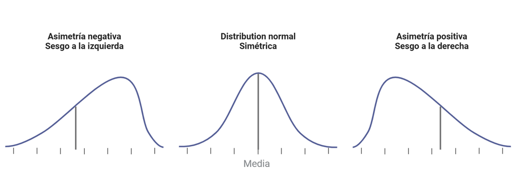

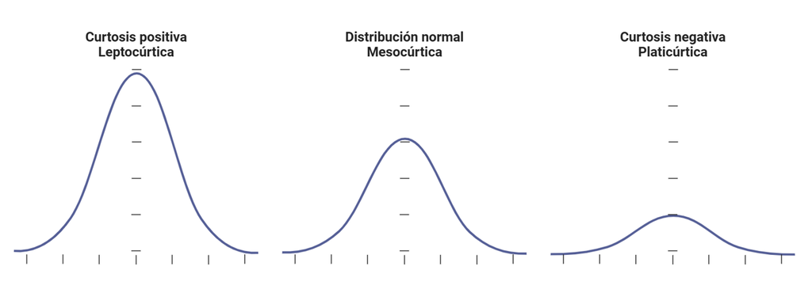

La función `descr()` del paquete `collapse` hace lo mismo que la función `describe()` pero nos muestra todas las variables por separado, no en una tabla:

```r
descr(datos)
```

```
## Dataset: datos, 4 Variables, N = 100
## --------------------------------------------------------------------------------
## sexo (factor):
## Statistics
##     N  Ndist
##   100      2
## Table
##    Freq  Perc
## F    53    53
## M    47    47
## --------------------------------------------------------------------------------
## altura (integer):
## Statistics
##     N  Ndist    Mean    SD  Min  Max  Skew  Kurt
##   100     46  160.04  15.2  130  192  0.05  2.37
## Quantiles
##    1%      5%  10%  25%  50%  75%    90%     95%  99%
##   130  136.95  139  149  160  171  180.1  184.25  192
## --------------------------------------------------------------------------------
## peso (integer):
## Statistics
##     N  Ndist   Mean     SD  Min  Max  Skew  Kurt
##   100     48  74.44  15.45   48  110  0.44  2.57
## Quantiles
##   1%     5%  10%  25%  50%    75%   90%     95%  99%
##   48  49.95   56   64   73  83.75  96.1  103.15  110
## --------------------------------------------------------------------------------
## edad (integer):
## Statistics
##     N  Ndist   Mean    SD  Min  Max  Skew  Kurt
##   100     32  34.71  9.82   18   50  0.04   1.8
## Quantiles
##      1%  5%  10%    25%   50%    75%  90%  95%  99%
##   18.99  20   21  26.75  34.5  43.25   49   50   50
## --------------------------------------------------------------------------------
```

También podemos explorar nuestras bases de datos con diferentes funciones del paquete `SmartEDA` que está dedicado al “Exploratory Data Analysis”:

```r
ExpData(datos, type = 1)
```

```
##                                           Descriptions    Value
## 1                                   Sample size (nrow)      100
## 2                              No. of variables (ncol)        4
## 3                    No. of numeric/interger variables        3
## 4                              No. of factor variables        1
## 5                                No. of text variables        0
## 6                             No. of logical variables        0
## 7                          No. of identifier variables        0
## 8                                No. of date variables        0
## 9             No. of zero variance variables (uniform)        0
## 10               %. of variables having complete cases 100% (4)
## 11   %. of variables having >0% and <50% missing cases   0% (0)
## 12 %. of variables having >=50% and <90% missing cases   0% (0)
## 13          %. of variables having >=90% missing cases   0% (0)
```

```r
ExpData(datos, type = 2)
```

```
##   Index Variable_Name Variable_Type Sample_n Missing_Count Per_of_Missing
## 1     1          sexo        factor      100             0              0
## 2     2        altura       integer      100             0              0
## 3     3          peso       integer      100             0              0
## 4     4          edad       integer      100             0              0
##   No_of_distinct_values
## 1                     2
## 2                    46
## 3                    48
## 4                    32
```

```r
ExpData(datos, type = 2, fun = c("mean", "median", "sd"))
```

```
##   Index Variable_Name Variable_Type Sample_n Missing_Count Per_of_Missing
## 1     1          sexo        factor      100             0              0
## 2     2        altura       integer      100             0              0
## 3     3          peso       integer      100             0              0
## 4     4          edad       integer      100             0              0
##   No_of_distinct_values   mean median    sd
## 1                     2     NA     NA    NA
## 2                    46 160.04  160.0 15.20
## 3                    48  74.44   73.0 15.45
## 4                    32  34.71   34.5  9.82
```

```r
ExpNumStat(datos, Outlier = TRUE)
```

```
##    Vname Group  TN nNeg nZero nPos NegInf PosInf NA_Value Per_of_Missing   sum
## 1 altura   All 100    0     0  100      0      0        0              0 16004
## 3   edad   All 100    0     0  100      0      0        0              0  3471
## 2   peso   All 100    0     0  100      0      0        0              0  7444
##   min max   mean median     SD    CV   IQR Skewness Kurtosis  LB.25%  UB.75%
## 1 130 192 160.04  160.0 15.197 0.095 22.00    0.050   -0.632 116.000 204.000
## 3  18  50  34.71   34.5  9.819 0.283 16.50    0.036   -1.200   2.000  68.000
## 2  48 110  74.44   73.0 15.445 0.207 19.75    0.436   -0.427  34.375 113.375
##   nOutliers
## 1         0
## 3         0
## 2         0
```

Si queremos ver un resumen descriptivo de nuestras variables numéricas agrupadas de acuerdo a una variable categórica, podemos utilizar la función `Summarize()` del paquete `FSA`:

```r
Summarize(altura ~ sexo, data = datos)
```

```
##   sexo  n     mean      sd min    Q1 median  Q3 max
## 1    F 53 151.9057 12.2353 130 142.0    152 161 181
## 2    M 47 169.2128 12.8688 139 159.5    171 178 192
```

Volver arriba

Inicio

#### Gráficos exploratorios

- **Histograma**: Muestra la distribución de frecuencias de los datos.

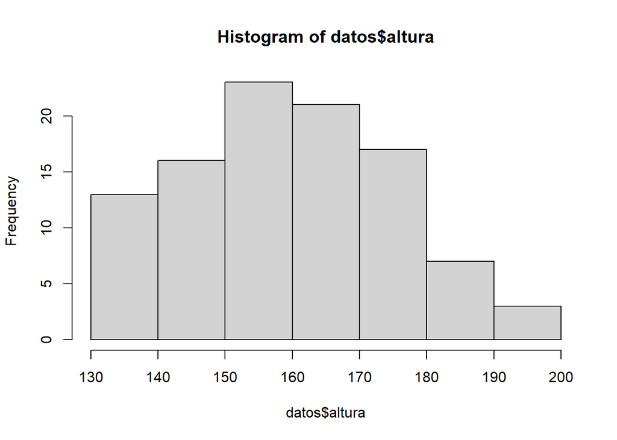

```r
hist(datos$altura)
```

- **Gráfico de caja (Boxplot)**: Resume la distribución de los datos y muestra valores atípicos.

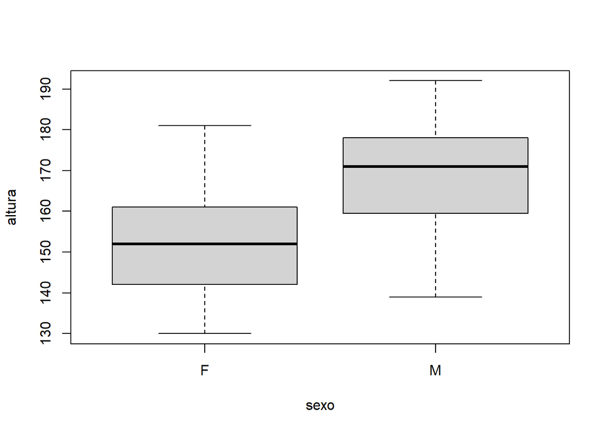

```r
boxplot(altura ~ sexo, data = datos)
```

- **Gráfico de barras**: Representa datos categóricos con barras proporcionales a su frecuencia.

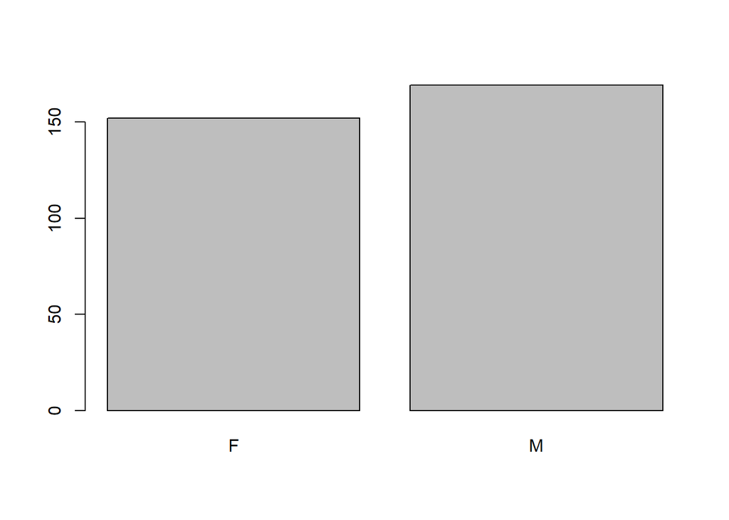

```r
media_altura <- tapply(datos$altura, datos$sexo, mean) # cálculo de la media de altura por sexo para el gráfico de barras
barplot(media_altura)
```

- **Gráfico de dispersión (scatter plot)**: Representa la relación entre dos variables.

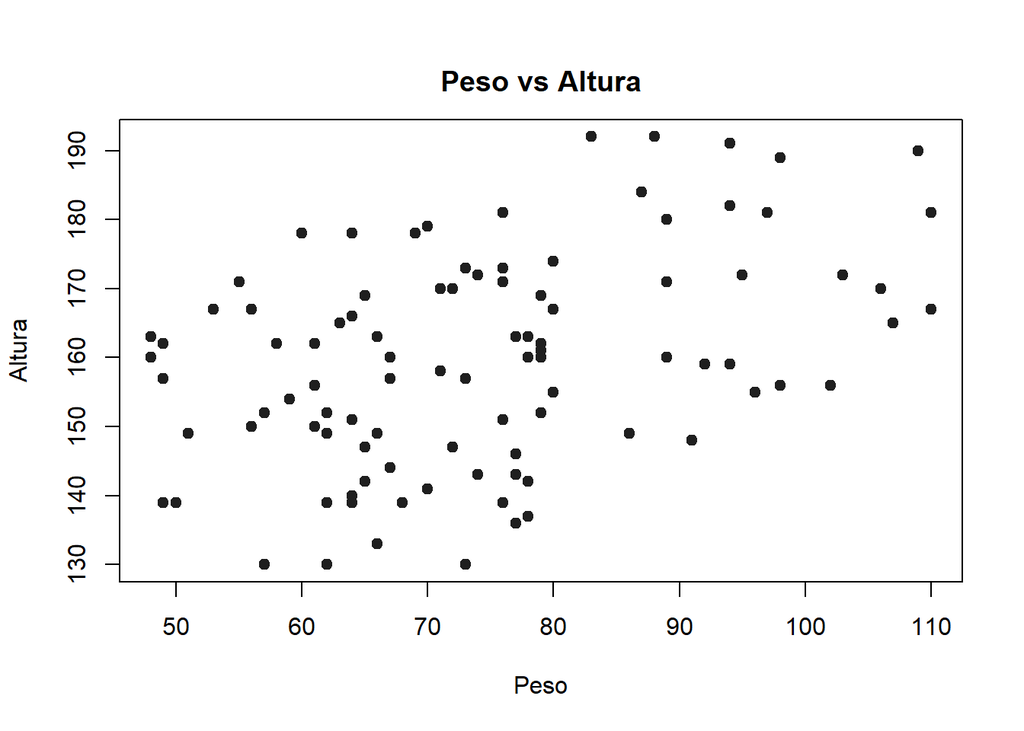

```r
plot(x = datos$peso, y = datos$altura,
     pch = 19, # `pch`, para indicar el estilo del símbolo (puede ser un valor del 1 al 25)
     cex = 1, # `cex`, para indicar el tamaño del símbolo
     col = "gray12", # `col`, para indicar el color del símbolo
     title("Peso vs Altura",
           adj = 0.5,
           line = 1), # `title`, para título (también puede ser el argumento main). `adj`, para ajustar la posición horizontal del título, valores entre 0 (izquierda) y 1 (derecha). `line`, para modificar la posicion vertical del título.
     xlab = "Peso", # `xlab`, para el título del eje x
     ylab = "Altura") # `ylab`, para el título del eje y)
```

Exploremos una tabla de datos más grande. La base de datos “penguins” del paquete `palmerpenguins` presenta medidas morfométricas de tres especies de pingüinos del Archipielago de Palmer en tres islas diferentes.

*Nota: Para consultar la información de bases de datos incluidas en paquetes de R podemos colocar el nombre de la base de datos en la pestaña de ayuda del panel inferior derecho o escribir “??penguins” en el script o directamente en la consola.*

Para cargar bases de datos incorporadas en paquetes de R, después de cargar el paquete solo debemos escribir `data()` y el nombre de la tabla de datos entre comillas (““).

```r
data("penguins")
head(penguins)
```

```
## # A tibble: 6 × 8
##   species island    bill_length_mm bill_depth_mm flipper_length_mm body_mass_g
##   <fct>   <fct>              <dbl>         <dbl>             <int>       <int>
## 1 Adelie  Torgersen           39.1          18.7               181        3750
## 2 Adelie  Torgersen           39.5          17.4               186        3800
## 3 Adelie  Torgersen           40.3          18                 195        3250
## 4 Adelie  Torgersen           NA            NA                  NA          NA
## 5 Adelie  Torgersen           36.7          19.3               193        3450
## 6 Adelie  Torgersen           39.3          20.6               190        3650
## # ℹ 2 more variables: sex <fct>, year <int>
```

El paquete `visdat` cuenta con funciones como `vis_dat()` para explorar el contenido de la base de datos

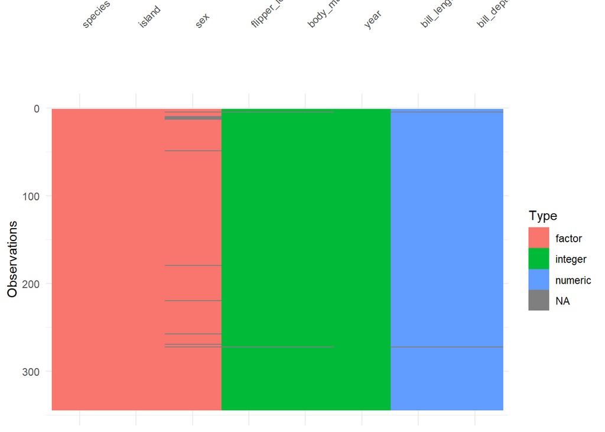

```r
vis_dat(penguins) # permite visulaizar todas las variables de nuestra tabla y su clase o tipo, la cantidad de observaciones y la presencia de valores NA (observaciones faltantes) en cada variable.
```

Para eliminar los valores NA de nuestra tabla:

```r
pinguinos <- na.omit(penguins)
```

El paquete `SmartEDA` es un paquete que cuenta con funciones para el análisis exploratorio de datos de manera automática.

```
## $`0`
```

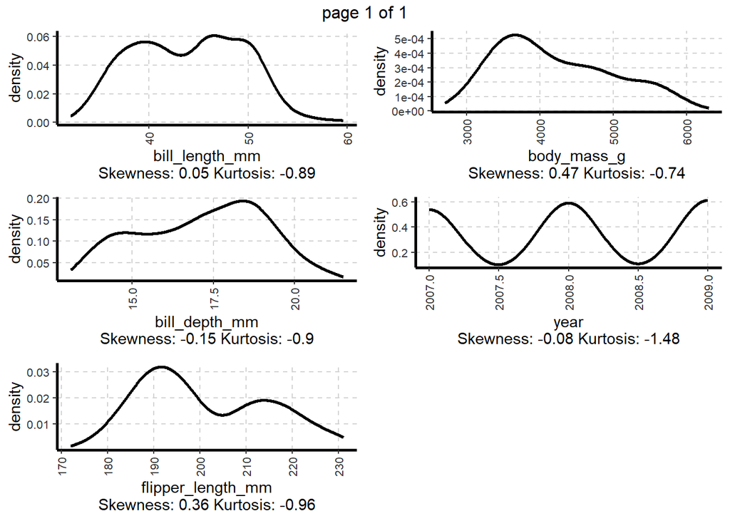

```r
ExpNumViz(pinguinos, Page = c(3,2)) # permite visualizar la distribución de todas las variables numéricas de nuestra tabla de datos con gráficos de densidad. El argumento `Page =` sirve para indicar el patrón de salida de los gráficos, con `c(3,2)` estamos indicando que los gráficos se muestren en 3 filas y 2 columnas. Si no colocamos `Page =` nos mostrará los gráficos de forma individual.
```

```
## $`0`
```

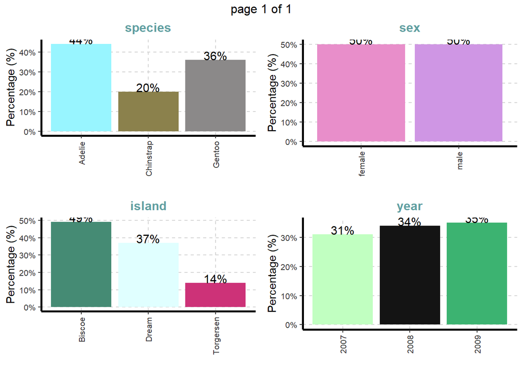

```r
ExpCatViz(pinguinos, Page = c(2,2)) # permite visualizar todas las variables categóricas de nuestra tabla de datos con gráficos de barra proporcionales a su frecuencia.
```

El paquete `ggplot2` dentro de `tidyverse` se especializa en la visualización de datos por medio de la gramática de gráficos (gg).

Los argumentos básicos para la función `ggplot()` son `data =` (nuestra tabla de datos), `aes()` (la estética del gráfico), donde especificamos las variables que irán en cada eje (x = “variablex”, y = “variabley”).

El `+` se utiliza para agregar elementos al gráfico.

Con la función `geom_...()` podemos agregar diferentes geometrías a nuestro gráfico (histogramas, puntos, líneas, barras, columnas, cajas, violines, entre otros).

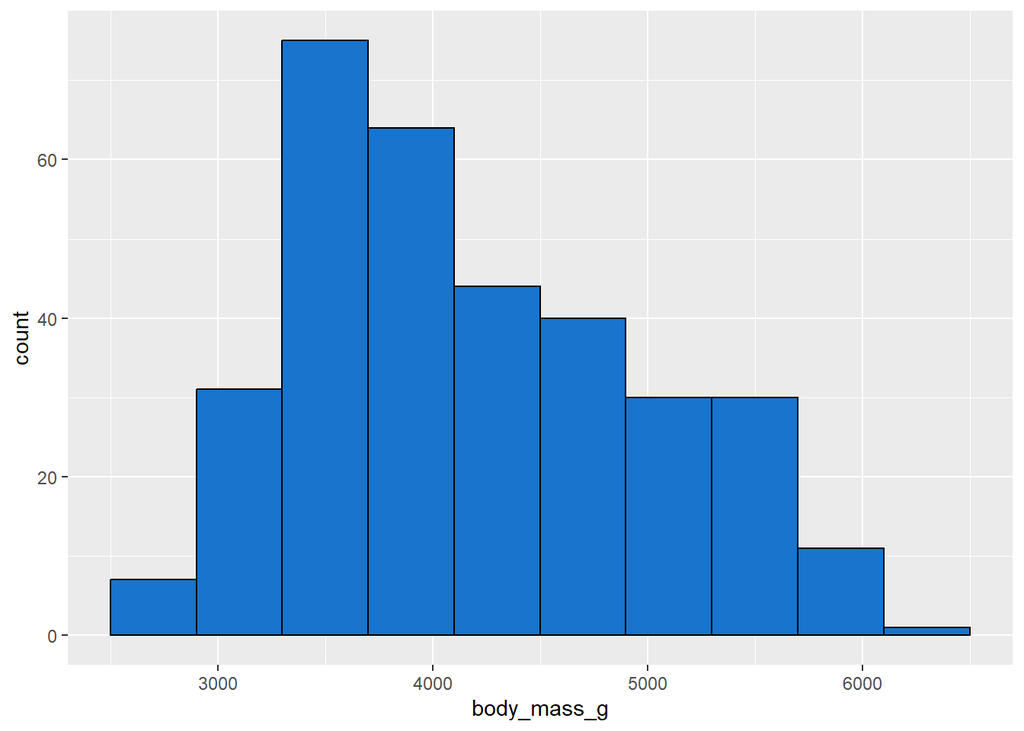

```r
# Histograma
ggplot(data = pinguinos, aes(x = body_mass_g)) +
  geom_histogram(fill = "dodgerblue3", # `fill` para rellenar
                 col = "black", # `col` para el color del borde
                 bins = 10) # para indicar el número de rangos de valores (secciones) en el eje x
```

```r
# Cada geometría puede modificarse con argumentos que se pueden consultar en la pestaña de ayuda escribiendo la geometría que se desea graficar, por ejemplo: `geom_histogram`.
```

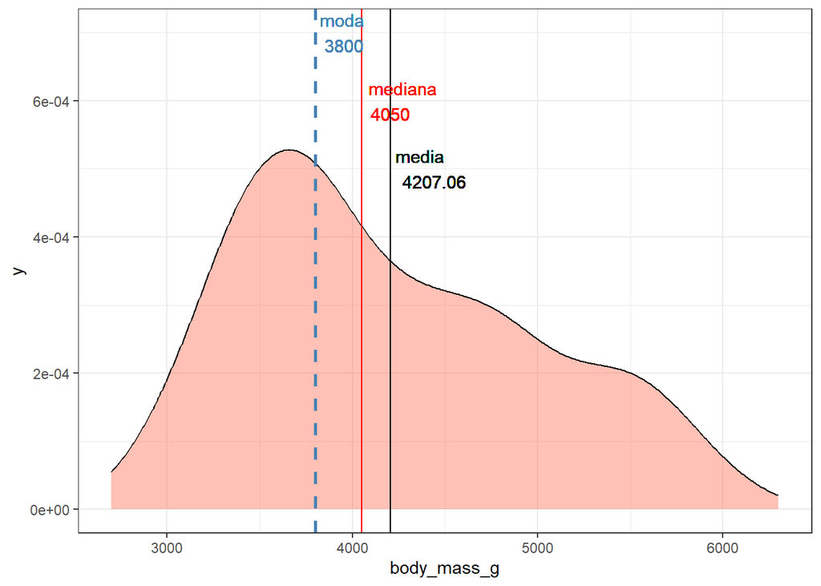

```r
# Gráfico de densidad
ggplot(pinguinos, aes(body_mass_g)) +
  geom_density(fill = "tomato",
               alpha = 0.4) + # `alpha` para indicar transparencia del relleno, valores de 0 (transparente) a 1 (sin transparencia)
  geom_vline(aes(xintercept = mean(body_mass_g))) + # grafica una línea vertical a partir de un intercepto en el eje x
  geom_text(aes(x = mean(body_mass_g),
                y = 0.0005,
                hjust = -0.1,
                label = paste("media\n", round(mean(body_mass_g),2)))) + # grafica texto dentro del gráfico en las coordenadas "x" y "y". `label` indica la etiqueta o el texto que se graficará
  geom_vline(aes(xintercept = median(body_mass_g)),
             color = "red") +
  geom_text(aes(x = median(body_mass_g),
                y = 0.0006,
                hjust = -0.1,
                label = paste("mediana\n", round(median(body_mass_g),2))),
            color = "red") +
  geom_vline(aes(xintercept = mlv(body_mass_g)),
             color = "steelblue",
             linetype = "dashed", # para cambiar el tipo de línea ("solid", "dashed", "dotted", "dotdash", "longdash", "twodash")
             linewidth = 1) + # para modificar el grosor de la línea
  geom_text(aes(x = mlv(body_mass_g),
                y = 0.0007,
                hjust = -0.1,
                label = paste("moda\n", round(mlv(body_mass_g),2))),
            color = "steelblue") +
  theme_bw()
```

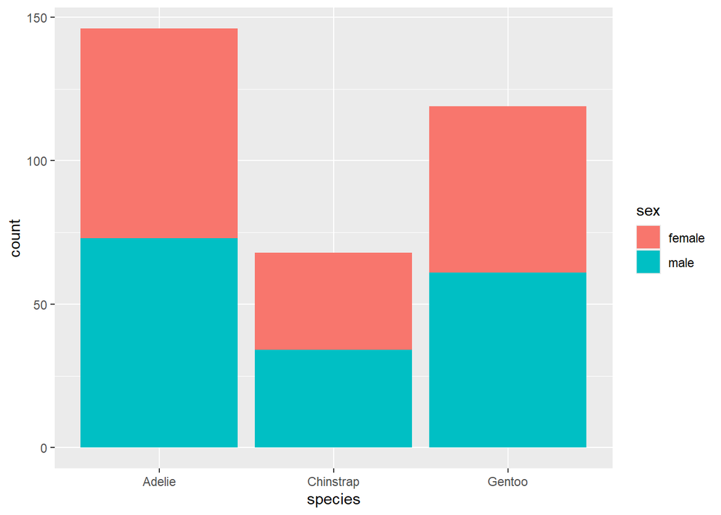

```r
# Gráfico de barras apiladas
ggplot(pinguinos, aes(species)) +
  geom_bar(aes(fill = sex)) # si queremos rellenar en base a una variable categórica de nuestra tabla de datos
```

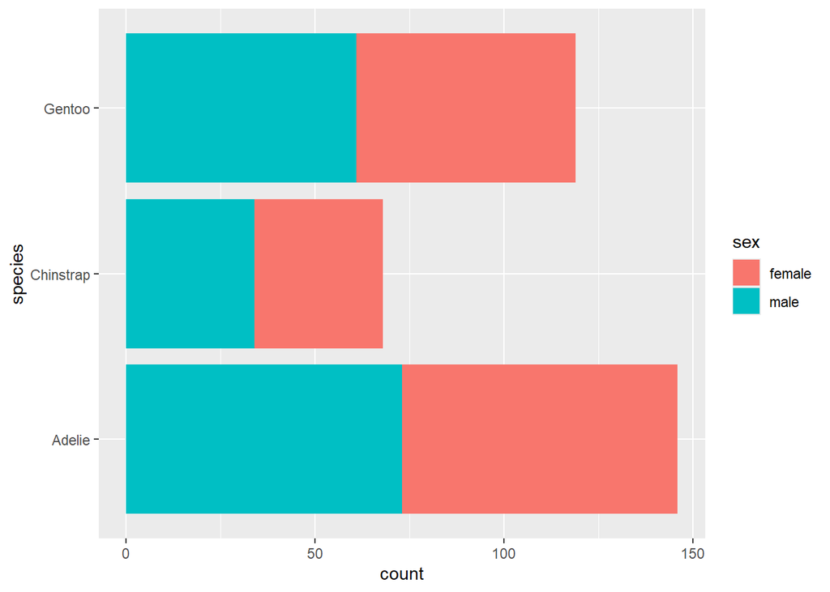

```r
# Gráfico de barras apiladas
ggplot(pinguinos, aes(species))+
  geom_bar(aes(fill = sex)) +
  coord_flip() # para cambiar de columnas verticales a barras horizontales
```

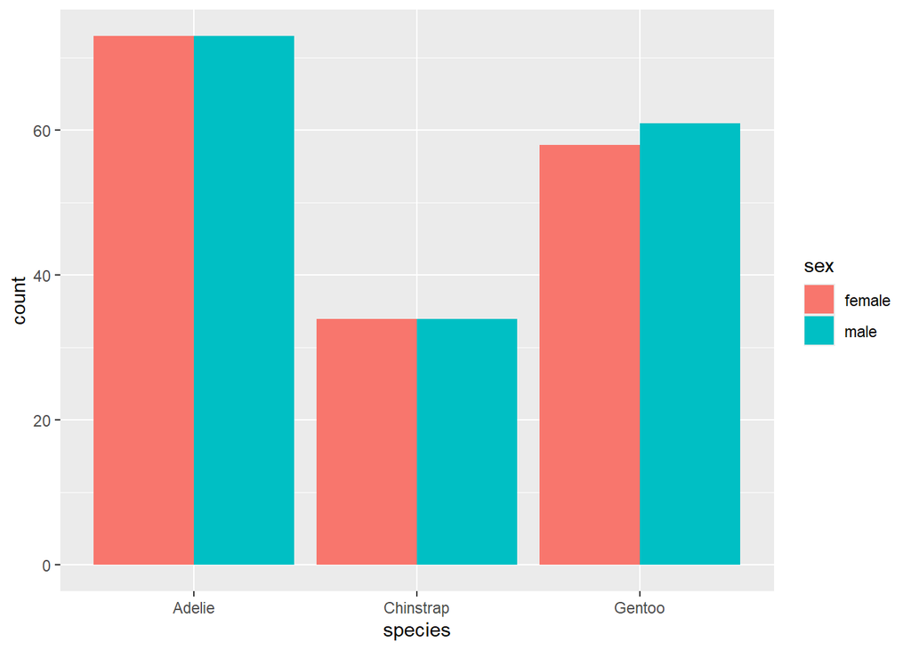

```r
# Gráfico de barras agrupadas
ggplot(pinguinos, aes(species)) +
  geom_bar(aes(fill = sex),
           position = "dodge") # para cambiar de columnas apiladas (`position = "stack"` [por defecto]) a columnas agrupadas.
```

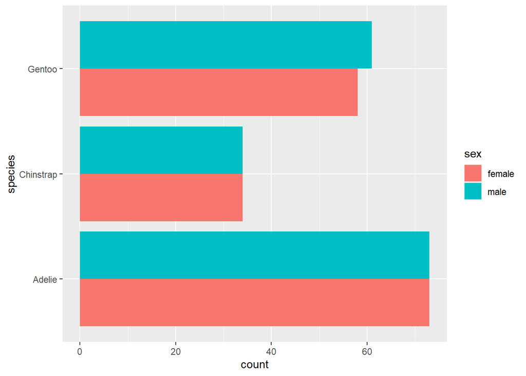

```r
# gráfico de barras agrupadas
ggplot(pinguinos, aes(species))+
  geom_bar(aes(fill = sex),
           position = "dodge") +
  coord_flip()
```

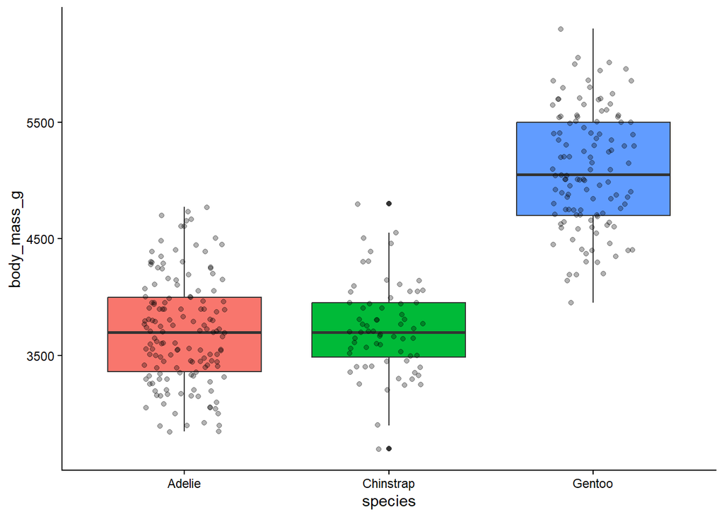

```r
# Grafico de cajas (Boxplot)
ggplot(pinguinos, aes(species, body_mass_g)) +
  geom_boxplot(aes(fill = species),
               show.legend = NULL) + # para ocultar la leyenda
  geom_jitter(width = 0.2, # `geom_jitter` para graficar puntos dispersos, `width` para especificar el ancho de la dispersión, valores de 0 (sin dispersión) a 1 (completamente dispersos)
              alpha = 0.3) +
  theme_classic() # con `theme_ ...` podemos escoger entre diferentes estilos de gráficos
```

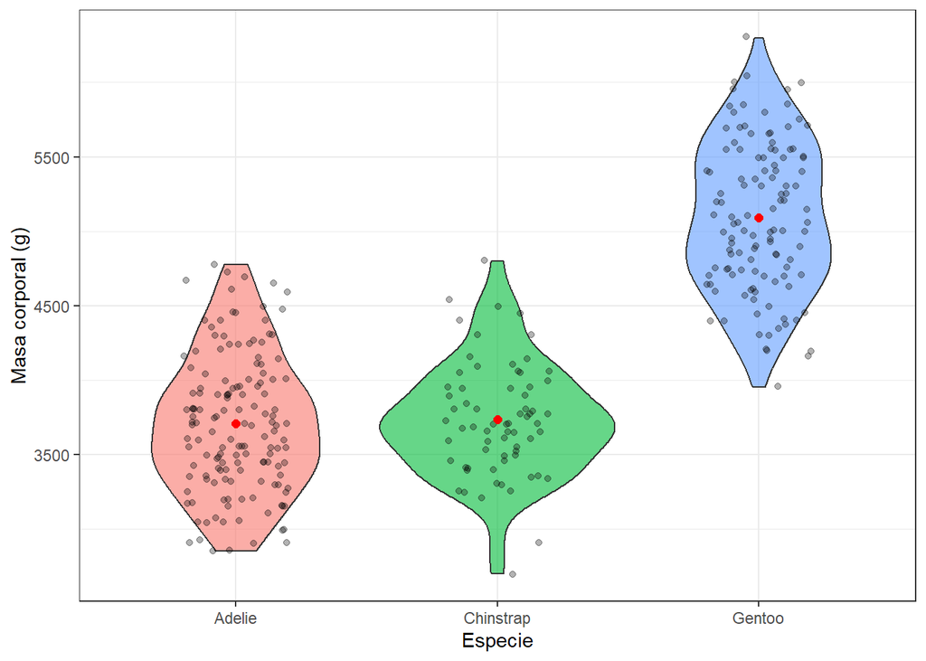

```r
# Gráfico de violín
ggplot(pinguinos, aes(species, body_mass_g)) +
  geom_violin(aes(fill = species),
              alpha = 0.6,
              show.legend = NULL) +
  geom_jitter(width = 0.2,
              alpha = 0.3) +
  stat_summary(fun = "mean", # para graficar un valor estadístico
               geom = "point", # para indicar el símbolo
               color = "red", # para indicar el color del símbolo
               size = 2) + # para indicar el tamaño del símbolo
  labs(x = "Especie",
       y = "Masa corporal (g)") +
  theme_bw()
```

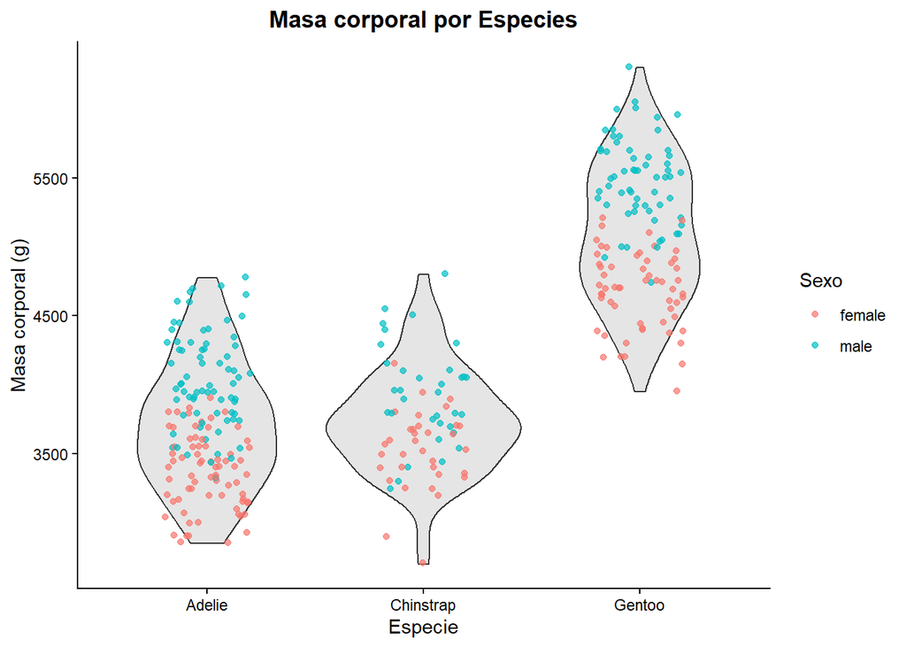

```r
# Gráfico de violín
ggplot(pinguinos, aes(species, body_mass_g)) +
  geom_violin(fill = "gray",
              alpha = 0.4,
              show.legend = NULL) +
  geom_jitter(aes(color = sex),
              width = 0.2,
              alpha = 0.7) +
  labs(title = "Masa corporal por Especies",
       x = "Especie",
       y = "Masa corporal (g)",
       color = "Sexo") + # `labs` para especificar el título del gráfico, de los ejes y la leyenda que estamos utilizando
  theme_classic() +
  theme(plot.title = element_text(hjust = 0.5,
                                  face = 2)) # `theme` es un argumento para modificar elementos en el gráfico, con `plot.title = element_text` modificamos el texto del título del gráfico, con `hjust` justificamos horizontalmente, valores de 0 (izquierda) a 1 (derecha)`face =` para modificar el estilo del texto (1 = normal, 2= negrita, 3 = cursiva, 4 = negrita + cursiva)
```

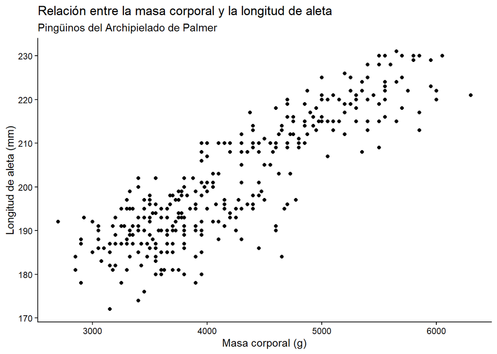

```r
# Gráfico de dispersión (Scatter plot)
ggplot(pinguinos, aes(body_mass_g, flipper_length_mm)) +
  geom_point() +
  labs(title = "Relación entre la masa corporal y la longitud de aleta",
       subtitle = "Pingüinos del Archipielado de Palmer",
       x = "Masa corporal (g)",
       y = "Longitud de aleta (mm)") +
  theme_classic()
```

##### Exportar gráficos

```r
ggsave("Imagenes/grafico_dispersion.jpg")
```

También podemos asignar nuestro gráfico a un objeto y especificarlo en la función `ggsave()`.

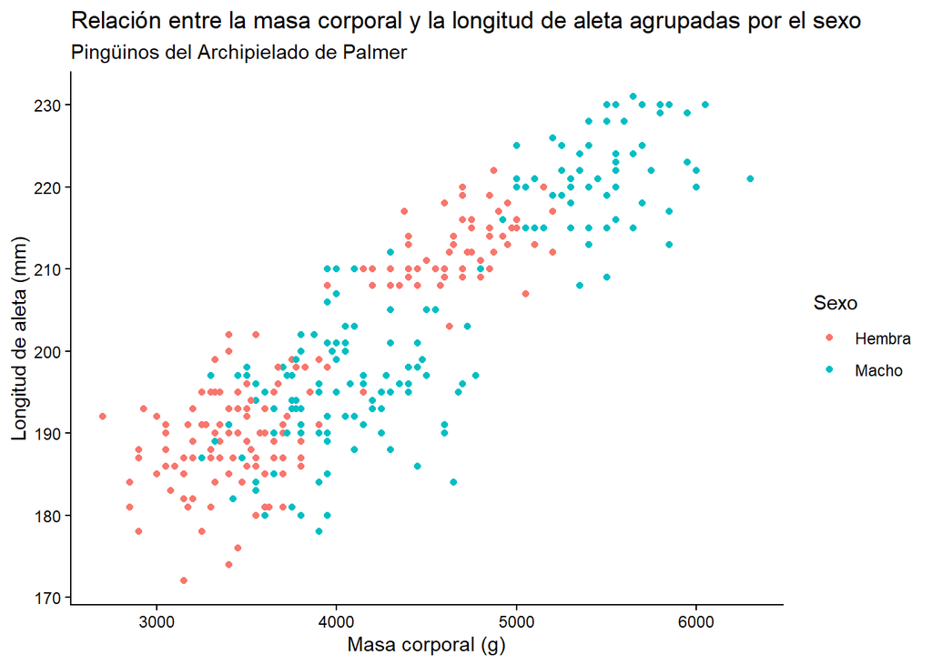

```r
# Gráfico de dispersión (Scatter plot)
dispersion <- ggplot(pinguinos, aes(body_mass_g, flipper_length_mm)) +
  geom_point(aes(color = sex)) +
  labs(title = "Relación entre la masa corporal y la longitud de aleta agrupadas por el sexo",
       subtitle = "Pingüinos del Archipielado de Palmer",
       x = "Masa corporal (g)",
       y = "Longitud de aleta (mm)",
       color = "Sexo") +
  scale_color_discrete(labels = c("Hembra", "Macho")) +
  theme_classic()
dispersion
```

```r
ggsave(plot = dispersion, # objeto que contiene nuestro gráfico
       "Imagenes/masaXaleta_dispersion.jpg",
       dpi = 450) # para modificar la calidad de salida en puntos por pulgada (300 dpi por defecto)

# también podemos modificar el ancho (`width`), la altura (`height`), las unidades (`units`), la escala (`scale`), entre otros.
```

Volver arriba

Inicio